# Yelp Rating Prediction Based on Text Review Sentiment Analysis

March 6, 2018

## Background

## Sentiment Analysis

- This refers to the use of natural language processing, text analysis, computational linguistics, and biometrics to systematically identify, extract, quantify, and study affective states and subjective information.
- Essentially this is a way to determine empirically the positivity/negativity of a statement

## Pre-processing Text

- When attempting sentiment analysis the text needs to be cleaned and prepared first
  - Remove words and symbols that don't add to the sentiment of the statement

`My wife took me here on my birthday for breakfast and it was excellent. The weather was perfect which made sitting outside overlooking their grounds an absolute pleasure.`

`['wife', 'took', 'birthday', 'breakfast', 'excellent', 'weather', 'perfect', 'made', 'sitting', 'outside', 'overlooking', 'grounds', 'absolute', 'pleasure']`

## Dataset

## Yelp Open Dataset

- The Yelp dataset is a subset of our businesses, reviews, and user data for use in personal, educational, and academic purposes. Available in both JSON and SQL files, use it to teach students about databases, to learn NLP, or for sample production data while you learn how to make mobile apps.
- 5,200,000 reviews
- 174,000 businesses
- 200,000 pictures
- 11 metropolitan areas
- 1,100,000 tips
- 1,300,000 users

## Yelp Open Dataset

- The only data we need in this massive dataset is the reviews JSON. Their structure resembles this:

| business_id | date | review_id | stars | text | type | user_id | cool | useful | funny |
| --- | --- | --- | --- | --- | --- | --- | --- | --- | --- |
| 9yKzy9PA… | 2011-01-26 | fWKvX8… | 5 | My wife took me… | review | rLtl… | 2 | 5 | 0 |
| ZRJwVLyz… | 2011-07-27 | IjZ33s… | 5 | I have no idea… | review | 0a2K… | 0 | 0 | 0 |
| 6oRAC4uy… | 2012-06-14 | IESLBz… | 4 | love the gyro… | review | 0hT2… | 0 | 1 | 0 |

## Yelp Review Dataset

- This JSON provides us with business_id, date, review_id, etc.
- Only really need stars and text to perform sentiment analysis
- However the text is unusable in it's current string format and needs pre-processed

```
def text_process(text):
    nopunc = [char for char in text if char not in string.punctuation]
    nopunc = ''.join(nopunc)
    return [word for word in nopunc.split()
            if word.lower() not in stopwords.words('english')]
```

## Basic Steps Involved

## Outline

- Access Yelp dataset JSON
- Isolate review JSON data
  - Possibly remove unnecessary JSON data to reduce filesize
- Preprocess data
- Convert reviews into a vector
- Split Yelp dataset into a smaller training dataset
- Train a few models
- Test and evaluate models
- Use review sentiment models to predict rating

## Outline

- Access Yelp dataset JSON
- Isolate review JSON data
  - Possibly remove unnecessary JSON data to reduce filesize
- Preprocess data
- Convert reviews into a vector
- Split Yelp dataset into a smaller training dataset
- Train a few models
  - <sub>Multinomial Naive Bayes</sub>
- Test and evaluate models
- Use review sentiment models to predict rating

## Accessing, Isolating, and Slimming

- The JSONs were pre-split into categories so after gaining access and downloading the dataset (6.52 GB) it was as simple as selecting the review.json file
- However, the dataset was too large to work with and I needed a subset of the data to test with and eventually use as my training data
  - I found a smaller subset of the review data containing only 10,000 reviews.
  - In the future I will randomly select a larger subset from the 5.2 million reviews in the dataset

## Accessing, Isolating, and Slimming

- For now working with the small dataset is convenient and both are identical structures
- In order to reduce size I decided to convert the JSON to a CSV
  - This reduced the size from 4.2 GB to ~3.7 GB
- I also tested removing unnecessary attributes to help reduce size
  - Removing type, business_id, date, review_id, user_id did not appear to have a sizable impact
  - Replacing text with only the pre-processed list did appear to have a sizable impact reducing the data further from 3.7 GB to ~3.2 GB

## Pre-processing Text

- Pre-processing is labor intensive, as it currently stands my laptop cannot pre-process the entire dataset during runtime
- So the intention is to find a more efficient pre-processing technique or store the pre-processed data in the dataset
  - Storing both the text and the list of pre-processed text takes our dataset's size from 3.7 GB to 6.9 GB

## Vectorization

- I used the bag-of-words approach where each unique word in a text will be represented by one number
  - Using SciKit-Learn's CountVectorizer function

```
bow_transformer = CountVectorizer(analyzer=text_process).fit(X)
```

- 26435 unique words
- Total word count of 222,391

## Multinomial Naive Bayes

- This was done using SciKit-Learn's CountVectorizer and MultinomialNB
- First I took a subset of the data

```
X_train, X_test, y_train, y_test
    = train_test_split(X, y, test_size=0.3, random_state=101)
```

- Then I applied the learning algorithm to the training set

```
MultinomialNB().fit(X_train, y_train)
```

## Analysis of Multinomial Naive Bayes

- Yielding a precision of 87% for 1 star reviews and 93% precision for 5 star reviews.
  - Discrepancy in precision due to there being a small training set which was taken from a set with a stronger bias towards higher scores

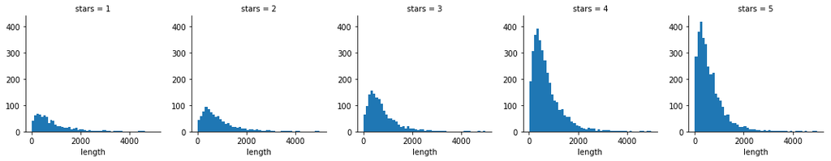

## Up Next

- More efficient vectorization
- Train a few more models
  - SVM
  - Nearest Centroid
- Test and evaluate models
- Use review sentiment models to predict rating